# DCGzoop

Rosie

2/18/2022

## Zoop data organization for DCG

First i need to get all the data from zooper. We probably need to decide which years to include, but I’ll start with 2000-2020 for now.

```r
#download zooper data and stick it together
Meso_data <- Zoopsynther(Data_type = "Community",
                         Sources = c("EMP",  "FMWT","STN","20mm"),
                         Size_class = "Meso",
                         Date_range = c("2000-01-01", "2020-12-31"))
```

```
## [1] "These species have no relatives in their size class common to all datasets and have been removed from one or more size classes: Ostracoda Adult (Meso), Cumacea Adult (Meso), Annelida Adult (Meso), Gammarus Adult (Meso), Orientomysis aspera Adult (Meso), Chironomidae Larva (Meso), Insecta Lar…
```

```r
Macro_data<-Zoopsynther(Data_type = "Community",
                        Sources = c("EMP",  "FMWT","STN"),
                        Size_class = "Macro",
                        Date_range = c("2000-01-01", "2020-12-31"))
```

```
## [1] "No disclaimers here! Enjoy the clean data!"
```

```r
Micro_data<-Zoopsynther(Data_type = "Community",
                        Sources = c("EMP"),
                        Size_class = "Micro",
                        Date_range = c("2000-01-01", "2020-12-31"))
```

```
## [1] "No disclaimers here! Enjoy the clean data!"
```

```r
Zooper_data<-Meso_data%>%rbind(Micro_data)%>%rbind(Macro_data)

#saveRDS(Zooper_data,"Data/Zooper_data.rds")
head(Zooper_data)
```

```
## # A tibble: 6 x 33
##   Source SizeClass Volume Lifestage Taxname   Taxlifestage SampleID  CPUE Phylum
##   <chr>  <chr>      <dbl> <chr>     <chr>     <chr>        <chr>    <dbl> <chr>
## 1 EMP    Meso        0.45 Adult     Acanthoc~ Acanthocycl~ EMP NZD~  716. Arthr~
## 2 EMP    Meso        0.45 Adult     Acartia_~ Acartia_UnI~ EMP NZD~    0  Arthr~
## 3 EMP    Meso        0.45 Adult     Acartiel~ Acartiella ~ EMP NZD~    0  Arthr~
## 4 EMP    Meso        0.45 Adult     Asplanch~ Asplanchna_~ EMP NZD~    0  Rotif~
## 5 EMP    Meso        0.45 Adult     Bosmina ~ Bosmina lon~ EMP NZD~ 5727. Arthr~
## 6 EMP    Meso        0.45 Adult     Calanoid~ Calanoida_U~ EMP NZD~    0  Arthr~
## # ... with 24 more variables: Class <chr>, Order <chr>, Family <chr>,
## #   Genus <chr>, Species <chr>, Undersampled <lgl>, Date <dttm>, Station <chr>,
## #   Chl <dbl>, Secchi <dbl>, Temperature <dbl>, BottomDepth <dbl>, Tide <chr>,
## #   Year <dbl>, Datetime <dttm>, Turbidity <dbl>, Microcystis <chr>, pH <dbl>,
## #   DO <dbl>, AmphipodCode <chr>, SalSurf <dbl>, SalBott <dbl>, Latitude <dbl>,
## #   Longitude <dbl>
```

## Now calculate biomass

```r
#Get biomass lookup tables in. I need to check and make sure this is the most recent version.
#it doesn't have "other cladocera" or the other UNIDS in it. But it's find to demo.
biomass_meso<-read_csv("Zooplankton/Data/biomass_mesomicro.csv")
biomass_meso<- mutate(biomass_meso,
                      Taxlifestage = paste(biomass_meso$Taxname,biomass_meso$Lifestage,sep=" "))%>%
                dplyr::select(Taxlifestage,Carbon_mass_micrograms)

Zoop_data = Zooper_data %>%
  mutate(Taxlifestage= str_replace(Taxlifestage, "_UnID",""),
         Taxlifestage = case_when(
           Taxlifestage=="Limnoithona Adult"~"Limnoithona tetraspina Adult",
           TRUE ~ Taxlifestage
         ))

#Meso-biomass calculations
#i'm going to skip the mysids for now, 'cause they are complicaated
Zoop_meso<-Zoop_data %>%
  filter(SizeClass%in%c("Meso","Micro"))

#join with biomass
Zoop_meso<-Zoop_meso%>%left_join(biomass_meso)
Zoop_meso$BPUE<-Zoop_meso$CPUE*Zoop_meso$Carbon_mass_micrograms


#load the spreadsheet of IBMR taxa
IBMRtaxa = read_csv("Zooplankton/zoopcrosswalk2.csv") %>%
  dplyr::select(Taxlifestage, IBMR) %>%
  distinct()
#get rid of undersampled taxa and add a "month" column
Zoop_datatest = left_join(Zoop_meso, IBMRtaxa) %>%
dplyr::filter(!Undersampled) %>%
  mutate(Month = month(Date))
head(Zoop_datatest)
```

```
## # A tibble: 6 x 37
##   Source SizeClass Volume Lifestage Taxname   Taxlifestage SampleID  CPUE Phylum
##   <chr>  <chr>      <dbl> <chr>     <chr>     <chr>        <chr>    <dbl> <chr>
## 1 EMP    Meso        0.45 Adult     Acanthoc~ Acanthocycl~ EMP NZD~  716. Arthr~
## 2 EMP    Meso        0.45 Adult     Acartia_~ Acartia Adu~ EMP NZD~    0  Arthr~
## 3 EMP    Meso        0.45 Adult     Acartiel~ Acartiella ~ EMP NZD~    0  Arthr~
## 4 EMP    Meso        0.45 Adult     Bosmina ~ Bosmina lon~ EMP NZD~ 5727. Arthr~
## 5 EMP    Meso        0.45 Adult     Calanoid~ Calanoida A~ EMP NZD~    0  Arthr~
## 6 EMP    Meso        0.45 Adult     Cladocer~ Cladocera A~ EMP NZD~ 1432. Arthr~
## # ... with 28 more variables: Class <chr>, Order <chr>, Family <chr>,
## #   Genus <chr>, Species <chr>, Undersampled <lgl>, Date <dttm>, Station <chr>,
## #   Chl <dbl>, Secchi <dbl>, Temperature <dbl>, BottomDepth <dbl>, Tide <chr>,
## #   Year <dbl>, Datetime <dttm>, Turbidity <dbl>, Microcystis <chr>, pH <dbl>,
## #   DO <dbl>, AmphipodCode <chr>, SalSurf <dbl>, SalBott <dbl>, Latitude <dbl>,
## #   Longitude <dbl>, Carbon_mass_micrograms <dbl>, BPUE <dbl>, IBMR <chr>,
## #   Month <dbl>
```

Now I want to add water year, water year type, and season

```r
#Calculate water year function
wtr_yr <- function(dates, start_month=12) {
  # Convert dates into POSIXlt
  dates.posix = as.POSIXlt(dates)
  # Year offset
  offset = ifelse(dates.posix$mon == start_month - 1, 1, 0)
  # Water year
  adj.year = dates.posix$year + 1900 + offset
  # Return the water year
  adj.year
}



Zoop_meso2 = mutate(Zoop_datatest,  Yearadj = wtr_yr(Date))

WYs = read_csv("yeartypes.csv")
WYs =  dplyr::rename(WYs, Yearadj = Year)
Zoop_meso = left_join(Zoop_meso2, WYs) %>%
  ungroup()
head(Zoop_meso)
```

```
## # A tibble: 6 x 41
##   Source SizeClass Volume Lifestage Taxname   Taxlifestage SampleID  CPUE Phylum
##   <chr>  <chr>      <dbl> <chr>     <chr>     <chr>        <chr>    <dbl> <chr>
## 1 EMP    Meso        0.45 Adult     Acanthoc~ Acanthocycl~ EMP NZD~  716. Arthr~
## 2 EMP    Meso        0.45 Adult     Acartia_~ Acartia Adu~ EMP NZD~    0  Arthr~
## 3 EMP    Meso        0.45 Adult     Acartiel~ Acartiella ~ EMP NZD~    0  Arthr~
## 4 EMP    Meso        0.45 Adult     Bosmina ~ Bosmina lon~ EMP NZD~ 5727. Arthr~
## 5 EMP    Meso        0.45 Adult     Calanoid~ Calanoida A~ EMP NZD~    0  Arthr~
## 6 EMP    Meso        0.45 Adult     Cladocer~ Cladocera A~ EMP NZD~ 1432. Arthr~
## # ... with 32 more variables: Class <chr>, Order <chr>, Family <chr>,
## #   Genus <chr>, Species <chr>, Undersampled <lgl>, Date <dttm>, Station <chr>,
## #   Chl <dbl>, Secchi <dbl>, Temperature <dbl>, BottomDepth <dbl>, Tide <chr>,
## #   Year <dbl>, Datetime <dttm>, Turbidity <dbl>, Microcystis <chr>, pH <dbl>,
## #   DO <dbl>, AmphipodCode <chr>, SalSurf <dbl>, SalBott <dbl>, Latitude <dbl>,
## #   Longitude <dbl>, Carbon_mass_micrograms <dbl>, BPUE <dbl>, IBMR <chr>,
## #   Month <dbl>, Yearadj <dbl>, Index <dbl>, Yr_type <chr>, Drought <chr>
```

A few quick plots

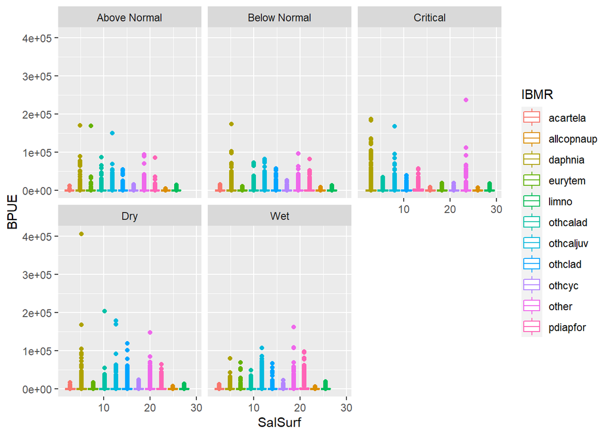

```r
ggplot(Zoop_meso, aes(x = SalSurf, y = BPUE, color = IBMR)) + geom_boxplot()+
  facet_wrap(~Yr_type)
```

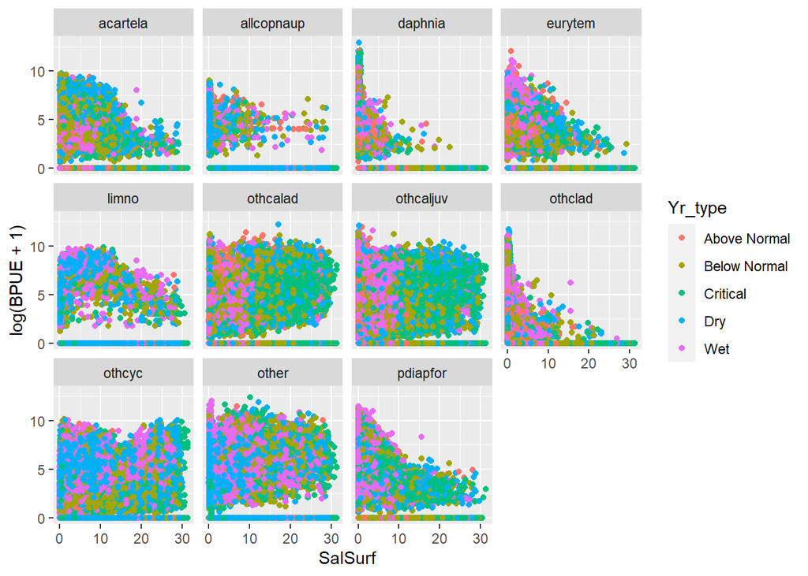

```r
ggplot(Zoop_meso, aes(x = SalSurf, y = log(BPUE+1), color =Yr_type)) + geom_point()+
  facet_wrap(~IBMR)
```

## summarize

Total BPUE per group by sample. Then average BPUE per station and month by water year type

```r
Zoop_mesoTot = group_by(Zoop_meso, SampleID, Volume, Source, SizeClass,
                        Yr_type, Latitude, Longitude, Station, Year, Month, Yearadj, IBMR) %>%
  dplyr::summarise(BPUEt = sum(BPUE, na.rm = T))
```

```
## 'Yr_type', 'Latitude', 'Longitude', 'Station', 'Year', 'Month', 'Yearadj'. You
## can override using the `.groups` argument.
```

```r
#Average zoop biomass by station, month, and water year type
Zoop_mesoSta = group_by(Zoop_mesoTot,  Source, Station,
                         Yr_type, Month, IBMR) %>%
  dplyr::summarise(BPUEm = mean(BPUEt, na.rm = T))
```

```
## can override using the `.groups` argument.
```

## load HSI data

I used .tiffs of habitat suitability that RMA ran for several scenarios of different water year types with and without SMSCG actions. Then I calculated the average HSI for each scenario in a 1 km buffer around each sampling station.

```r
#load habitat by station
load("HabitatbyStations.RData")

names(IEP_sf_HSI)
```

```
##  [1] "...1"
##  [2] "StationCode"
##  [3] "Survey"
##  [4] "SubRegion"
##  [5] "SQM"
##  [6] "Region"
##  [7] "mean.smscg_1940.06_hsit.avgmon_rma"
##  [8] "mean.smscg_1940.07_hsit.avgmon_rma"
##  [9] "mean.smscg_1940.08_hsit.avgmon_rma"
## [10] "mean.smscg_1940.09_hsit.avgmon_rma"
## [11] "mean.smscg_1940.10_hsit.avgmon_rma"
## [12] "mean.smscg_1979.06_hsit.avgmon_rma"
## [13] "mean.smscg_1979.07_hsit.avgmon_rma"
## [14] "mean.smscg_1979.08_hsit.avgmon_rma"
## [15] "mean.smscg_1979.09_hsit.avgmon_rma"
```

[output cut: 22 more lines]

```r
IEP_sf_HSI = dplyr::rename(IEP_sf_HSI, Station = StationCode, Source = Survey)
IEP_HSI_long = st_drop_geometry(IEP_sf_HSI) %>%
  pivot_longer(cols =  starts_with("mean"),
                            names_to = "Scenario", values_to = "HSI")

#import scenario descriptions
scenarios = read_csv("ScenariosRMA.csv")
IEP_HSI_long = left_join(IEP_HSI_long, scenarios)
IEP_wzoop = left_join(Zoop_mesoSta, IEP_HSI_long)
```

To look at what the zooplankton biomass in the “good” habitat is, I first tried cutting off the “good” habitat at an HSI above 0.4

```r
IEP_zoop_goodHSI = filter(IEP_wzoop, HSI > 0.4) %>%
  group_by(Scenario, IBMR, Yr_type, Month, Action) %>%
  dplyr::summarize(BPUE = mean(BPUEm, na.rm = T))
```

```
## can override using the `.groups` argument.
```

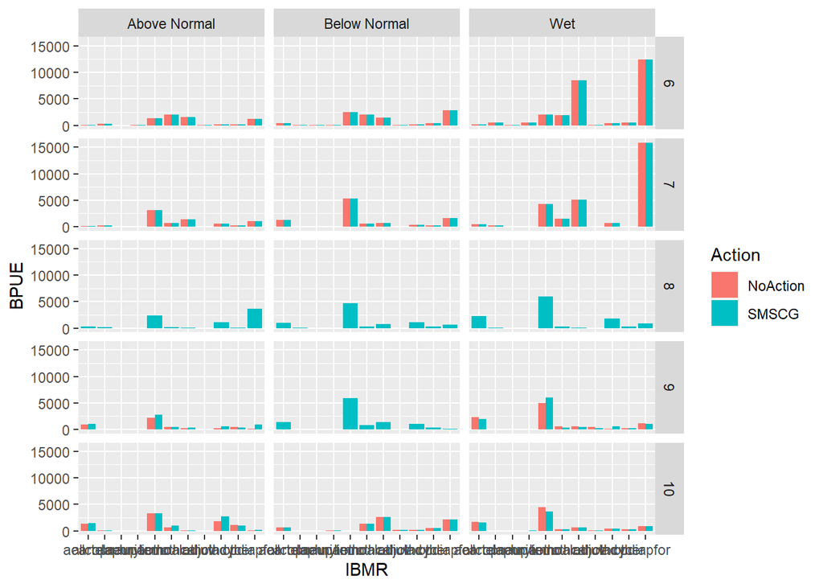

```r
ggplot(IEP_zoop_goodHSI, aes(x = IBMR, y = BPUE, fill = Action)) + geom_col(position = "dodge")+
  facet_grid(as.factor(Month)~Yr_type)
```

```r
#Damn it. I don't know that this is actually going to work.
```

That didn’t show a lot of difference bewteen scenarios. Next I will try weighting the BPUE by the HSI, rather than using a cut-off.

```r
IEP_zoop_goodHSI2 =mutate(IEP_wzoop, foodHSI = BPUEm*HSI) %>%
  filter(!is.na(HSI)) %>%
  group_by(Scenario, IBMR, Yr_type, Month, Action) %>%
  dplyr::summarize(BPUEweighted = mean(foodHSI, na.rm = T))
```

```
## can override using the `.groups` argument.
```

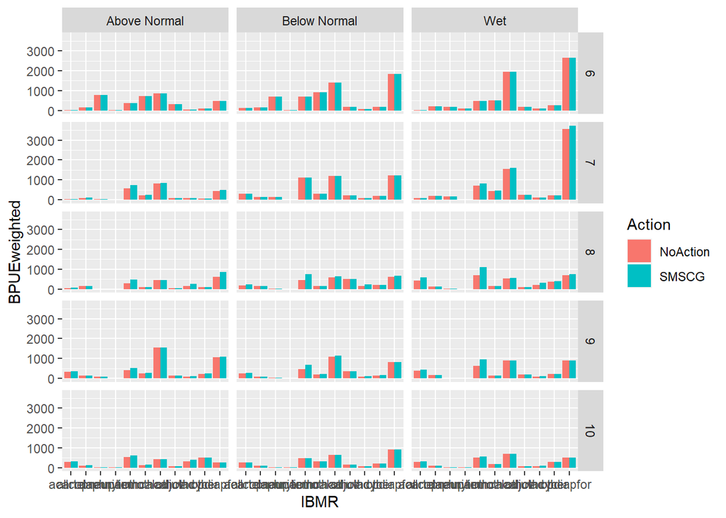

```r
ggplot(IEP_zoop_goodHSI2, aes(x = IBMR, y = BPUEweighted, fill = Action)) + geom_col(position = "dodge")+
  facet_grid(as.factor(Month)~Yr_type)
```

OK, that’s something. Let’s put it in terms of a difference between actions.

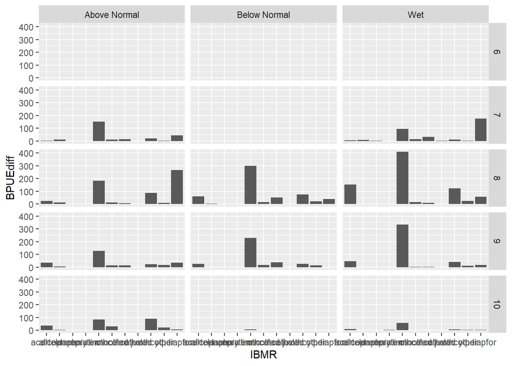

```r
IEP_zoop_goodHSI3 = IEP_zoop_goodHSI2 %>%
  pivot_wider(id_cols = c(IBMR, Yr_type, Month), names_from = Action, values_from = BPUEweighted) %>%
  mutate(BPUEdiff = SMSCG - NoAction, BPUEperdiff = 1-(NoAction/SMSCG))


ggplot(IEP_zoop_goodHSI3, aes(x = IBMR, y = BPUEdiff)) + geom_col(position = "dodge")+
  facet_grid(as.factor(Month)~Yr_type)
```

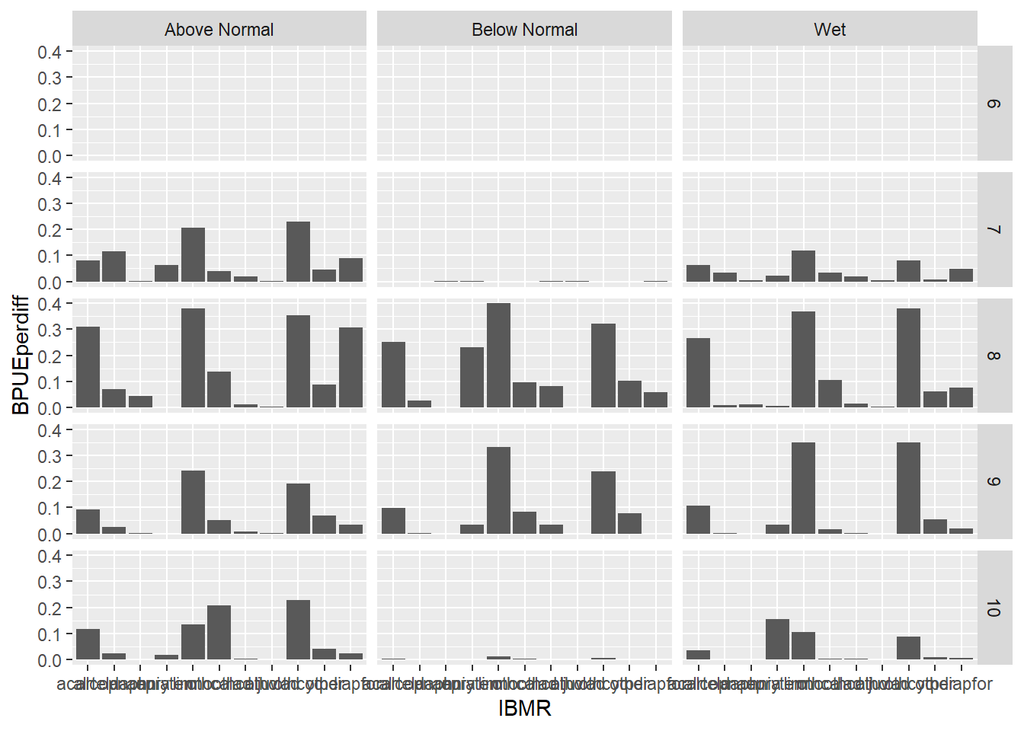

```r
ggplot(IEP_zoop_goodHSI3, aes(x = IBMR, y = BPUEperdiff)) + geom_col(position = "dodge")+
  facet_grid(as.factor(Month)~Yr_type)
```

```r
#OK! This is something I can work with!!!

#I need to look at the details, but I think this is something useful. HIgher values for SMSCG action anyway.
```